# Personal Porfolio Management

Julian Ghadially

December 21, 2015

### Goal

The goal of this analysis is to optimize a porfolio of index funds to acheive the benefits of diversification and to maximize my return given my risk level.  
Crucial to this is to determine optimal weights for each asset in my portfolio. At this time, I am starting out with an existing portfolio (see portfolio 1 under the “Assets” subsection), whose weights should be adjusted according to the results of this analysis.

### Outline

1. Introduction
2. Exploratory Data Analysis
3. Risk-return analysis using Monte Carlo simulation of several possible positions amongst different asset classes
   - Intended as a rough, preliminary analysis
4. Risk-return analysis using more accurate financial calculations
5. Identify Efficient Portfolio Frontier and my level of risk

### Introduction

An investment strategy based on index funds has the advantage of low cost expense ratios, diversification, protection against human error, and passive management for the investor. Furthermore, professional money managers and actively managed funds that try to outperform the market have performed worse on average than index funds that try to track the market.  
In my investments, I have struggled to provide myself with concrete evidence to justify a given allocation between varying index funds. The purpose of this analysis is to determine these weights. Given that each index fund is essentially completely diversified within its own market (ie. they have removed almost all unique risk of securities within that market), It could potentially be overkill to try to diversify further between markets. This analysis should help determine whether that’s the case.

**Assets**  
There are four funds under consideration:  
1. Vanguard Total Stock Market Index Fund (VTSMX)  
2. Vanguard Total Bond Market Index Fund (VBMFX)  
3. Vanguard Small-Cap Index Fund (NAESX) 4. Vanguard Emerging Markets Stock Index (VEIEX)

Data for these funds are obtained from Yahoo Finance for the last decade, from November 30, 2005 to November 30, 2015. Each year has 260 trading days.

### Exploratory Analysis

**Individual Fund Risk and Returns**

| Fund | Return | Risk (annual standard deviation of daily returns) |
| --- | --- | --- |
| VTSMX | 7.63% | 20.73% |
| VBMFX | 4.51% | 4.07% |
| NAESX | 8.27% | 24.65% |
| VEIEX | 4.12% | 25.31% |

These calculations also match the quoted 10-year annual effective returns listed on Vanguard.com, as of their November 30, 2015 update.

**Volatility: Beta’s and Correlation Matrix**

Beta’s (see below) are acquired using SPY as a proxy for the market portfolio. The assumption is that the market portfolio is an efficient portfolio.

```
##          VTSMX       VBMFX    NAESX    VEIEX
## Betas 1.009328 -0.06643197 1.127878 1.073002
```

The bond market index fund is the least exposed to the systematic risk of the US stock market, as expected, with a beta of -0.066.

Correlation Matrix

```
##                 VTSMX.PctReturn VBMFX.PctReturn NAESX.PctReturn
## VTSMX.PctReturn       1.0000000      -0.3455208       0.9610295
## VBMFX.PctReturn      -0.3455208       1.0000000      -0.3270465
## NAESX.PctReturn       0.9610295      -0.3270465       1.0000000
## VEIEX.PctReturn       0.8595485      -0.2832526       0.8144400
##                 VEIEX.PctReturn
## VTSMX.PctReturn       0.8595485
## VBMFX.PctReturn      -0.2832526
## NAESX.PctReturn       0.8144400
## VEIEX.PctReturn       1.0000000
```

In order to receive the benefits of diversification, it is crucial to use uncorrelated inputs. Thus, I use the correlation matrix from above to gauge how these different securities interact in a portfolio. From the correlation matrix above, we see that the bond market is the least correlated with the total stock market, with a correlation of -0.346. However, the small stock index has a very high correlation of 0.96 with the total stock index. Given that the current portfolio is weighted heavily in the VTSMX, the small stock index is not providing very much diversification benefits. Its purpose would be to make a bet on small cap firms, which tend to have slightly larger returns over time than large cap firms.

Theoretically, the only thing that matters when adding an asset to a diversified portfolio is how it covaries with the portfolio. (This concept is derived from Markowitz’s variance of a portfolio equation combined with the theory behind the capital allocation line). For a portfolio that reflects the market, what matters when adding an asset is its covariance with the market. The beta for stock x is related to covariance with the market in that the beta (like the coefficient for any other regression) is equal to covariance(stock x, market)/Var(market).

### Risk-Return Analysis of Portfolios

Portfolio 1: Current Portfolio VTSMX: 52.02%, VBMX: 30.03%, NAESX: 17.95%, VEIEX: 0%

Portfolio 2: Stock Heavy With Emerging Markets VTSMX: 50%, VBMX: 10%, NAESX: 20%, VEIEX: 20%

Portfolio 3: Even-Split VTSMX: 25%, VBMX: 25%, NAESX: 25%, VEIEX: 25%

The expected return of a portfolio can be calculated using the weighted average return of each asset. The standard deviation of a portfolio can be calculated by summing the weighted variances and correlation of each stock with the portfolio (defined by Markowitz).

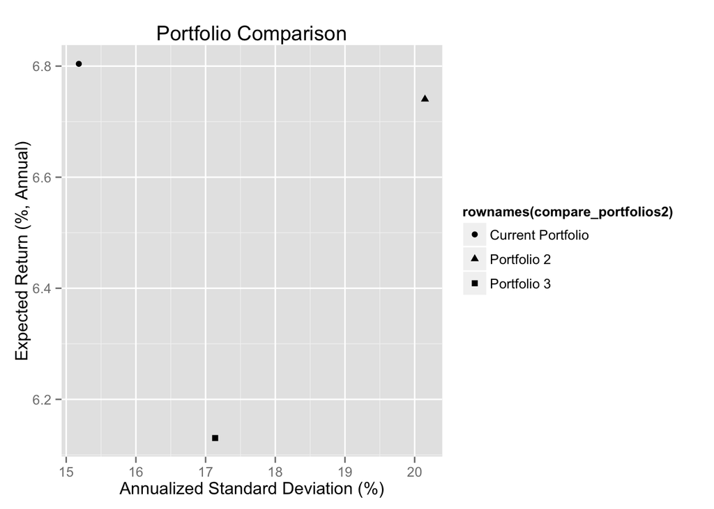

We see from the graph above that the stock-heavy Portfolio 2 is the riskiest portfolio. The current portfolio has the largest return and is also the least risky. As a young investor, I should be willing to accept more risk for more reward. The purpose of these calculations is to give a rough estimate of the current situation against alternatives. Next, I will identify the efficient portfolio frontier and see how far away I am from it.

### Efficient frontier from four-asset combinations

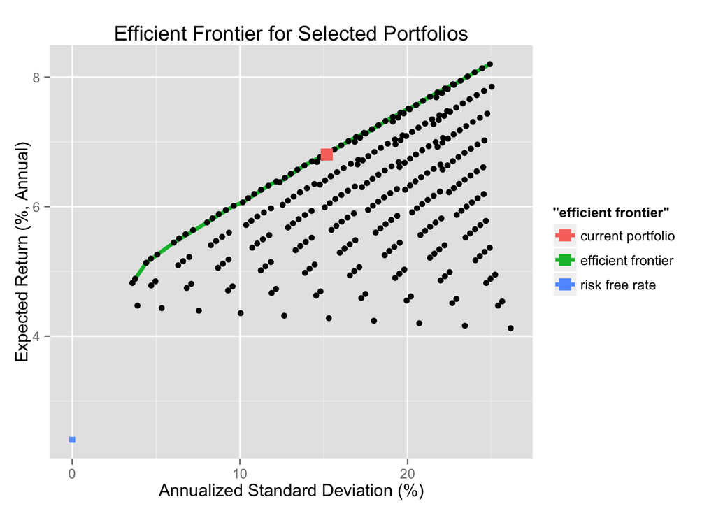

While the efficient frontier I have generated is useful, it is based on historical data, which may not be indicative of the future. The optimal portfolio weightings that are implied by this efficient frontier may be optimal simply because some of the fund performed better or worse over the last decade. Having said that, we see that the current porfolio is already on the efficient frontier, but that more risk can be taken on to generate more return, if appropriate for the investor’s risk profile.  
Let’s take a look at each of the four funds, below, to see what effect they are having, and to (hopefully) determine the optimal weighting.

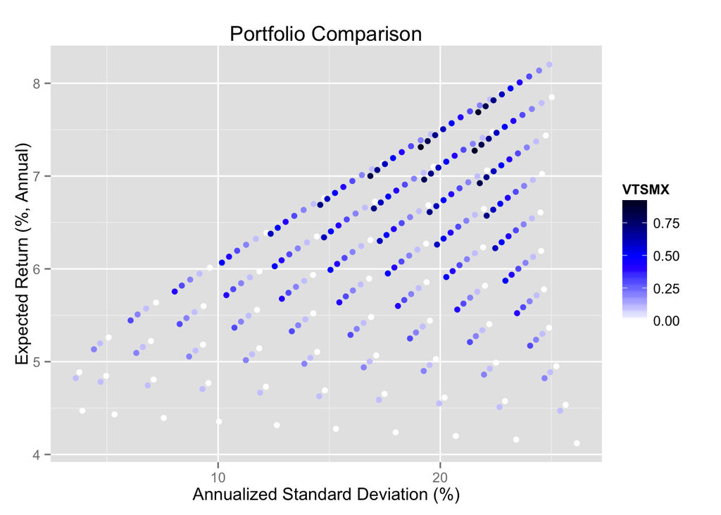

In this chart and the next few portfolio comparison charts, I have removed the efficient frontier line to clearly depict the effect of each fund, but it is useful to visualize the frontier. As we can see, there are some points on the efficient frontier that include the VTSMX. However, weighting too heavily in the VTSMX resulted in suboptimal positions below the efficient frontier during the last ten years. Lets look at the effect of the other funds.

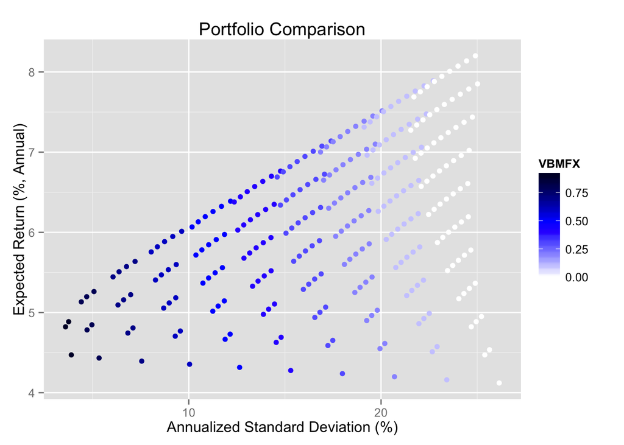

The bond market fund, as expected helps us decrease our overall risk, but this comes with less return. As a young investor, I should be willing to accept more risk then most.

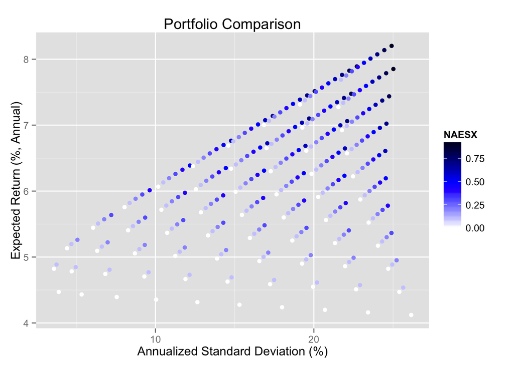

The small stock index, NAESX, performed quite nicely over the last ten years. In fact, small stocks tend to be popular, in part, for this reason. Within each cluster, we see that moving from white (0 weight) to the darkest blue of the cluster would have historically given us a moderate difference in returns, in exchange for taking on extra risk.

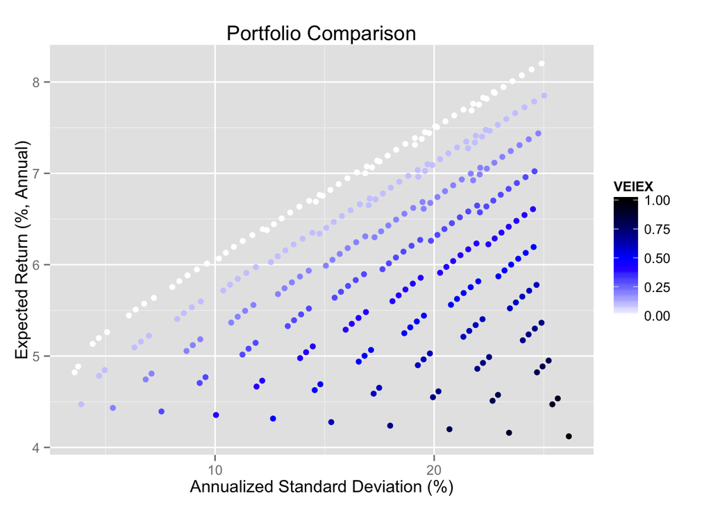

### Conclusion

An important consideration in answering what the weights should be is the fact that past performance is not indicative of future success. If one chooses the weights that worked in the past decade, one has no guarantee that it is optimal for the future. Furthermore, the entire strategy of using index funds is simply to try to track the market, rather than pick the best performing securities.  
If one were to follow the implications of these portfolio comparisons, One would never own the VEIEX. However, to exclude it would be trying to beat the market. Futhermore, if markets truly are efficient, the risk in the emerging markets would be incorporated into the prices of the securities it encompasses, and it would ultimately return as much as similarly risky funds.

*So what should the weights be?*  
Given that I’m a young investor, I could increase my risk a little by weighting more of the small stock fund (NAESX). I should also add VEIEX to the portfolio so that I can appropriately track the market, even though this would bring the portfolio off of the efficient frontier.

Of course, this conclusion is not based on the analysis. I deviate from the results because history does not indicate future success, and I’d rather follow the original strategy, which was to track the market. More importantly, comparing these portfolios is very helpful for measuring and visualizing the risk:return ratios of different funds and the portfolios that include them.